# Week 6 - Document Clustering with Daily Kos

Vishal Gupta

3/31/2019

```r
library(dplyr)
library(rpart)
library(rpart.plot)
library(caTools)
library(ROCR)
library(randomForest)
library(tm)
library(SnowballC)
```

#### Problem 1.1 - Hierarchical Clustering

Let’s start by building a hierarchical clustering model. First, read the data set into R. Then, compute the distances (using method=“euclidean”), and use hclust to build the model (using method=“ward.D”). You should cluster on all of the variables.

```r
dailykos = read.csv("~/Downloads/dailykos.csv")
dim(dailykos)
```

```
## [1] 3430 1545
```

```r
distances = dist(dailykos, method = "euclidean")
clusterDailyKos = hclust(distances, method = "ward.D")
```

Running the dist function will probably take you a while. Why? Select all that apply.

- **We have a lot of observations, so it takes a long time to compute the distance between each pair of observations.**
- **We have a lot of variables, so the distance computation is long.**
- Our variables have a wide range of values, so the distances are more complicated.
- The euclidean distance is known to take a long time to compute, regardless of the size of the data.

#### Problem 1.2 - Hierarchical Clustering

Plot the dendrogram of your hierarchical clustering model. Just looking at the dendrogram, which of the following seem like good choices for the number of clusters? Select all that apply.

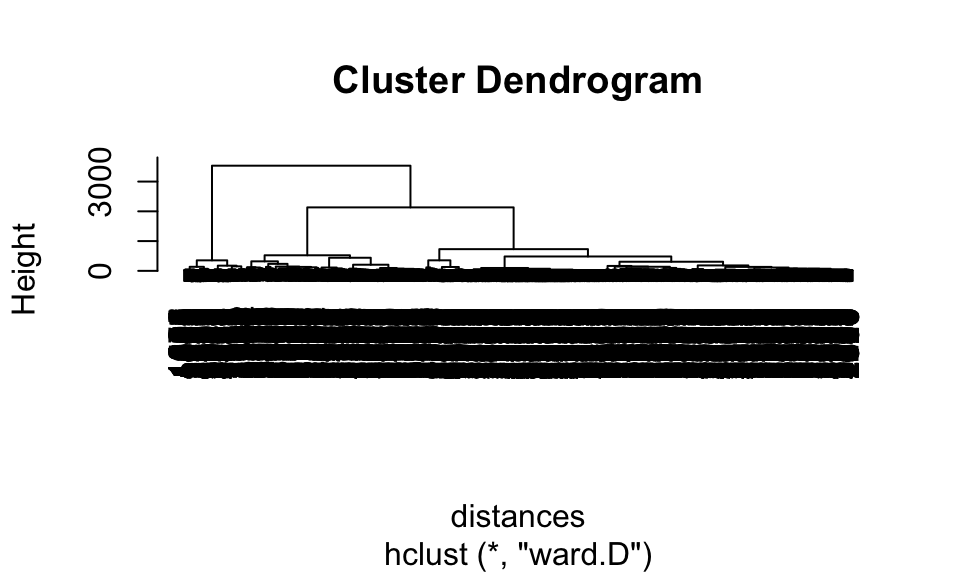

```r
plot(clusterDailyKos)
```

- **2**
- **3**
- 5
- 6

#### Problem 1.3 - Hierarchical Clustering

In this problem, we are trying to cluster news articles or blog posts into groups. This can be used to show readers categories to choose from when trying to decide what to read. Just thinking about this application, what are good choices for the number of clusters? Select all that apply.

- 2
- 3
- **7**
- **8**

#### Problem 1.4 - Hierarchical Clustering

Let’s pick 7 clusters. This number is reasonable according to the dendrogram, and also seems reasonable for the application. Use the cutree function to split your data into 7 clusters.

```r
clusterGroups = cutree(clusterDailyKos, k = 7)
```

Now, we don’t really want to run tapply on every single variable when we have over 1,000 different variables. Let’s instead use the subset function to subset our data by cluster. Create 7 new datasets, each containing the observations from one of the clusters.

```r
dailykosC1 = subset(dailykos, clusterGroups == 1)
dailykosC2 = subset(dailykos, clusterGroups == 2)
dailykosC3 = subset(dailykos, clusterGroups == 3)
dailykosC4 = subset(dailykos, clusterGroups == 4)
dailykosC5 = subset(dailykos, clusterGroups == 5)
dailykosC6 = subset(dailykos, clusterGroups == 6)
dailykosC7 = subset(dailykos, clusterGroups == 7)
table(clusterGroups)
```

```
## clusterGroups
##    1    2    3    4    5    6    7
## 1266  321  374  139  407  714  209
```

How many observations are in cluster 3?

**374**

Which cluster has the most observations?

- **Cluster 1**
- Cluster 2
- Cluster 3
- Cluster 4
- Cluster 5
- Cluster 6
- Cluster 7

Which cluster has the fewest observations?

- Cluster 1
- Cluster 2
- Cluster 3
- **Cluster 4**
- Cluster 5
- Cluster 6
- Cluster 7

#### Problem 1.5 - Hierarchical Clustering

Instead of looking at the average value in each variable individually, we’ll just look at the top 6 words in each cluster. To do this for cluster 1, type the following in your R console (where “HierCluster1” should be replaced with the name of your first cluster subset):

tail(sort(colMeans(HierCluster1)))

This computes the mean frequency values of each of the words in cluster 1, and then outputs the 6 words that occur the most frequently. The colMeans function computes the column (word) means, the sort function orders the words in increasing order of the mean values, and the tail function outputs the last 6 words listed, which are the ones with the largest column means.

What is the most frequent word in this cluster, in terms of average value? Enter the word exactly how you see it in the output:

```r
tail(sort(colMeans(dailykosC1)))
```

```
##      state republican       poll   democrat      kerry       bush
##  0.7575039  0.7590837  0.9036335  0.9194313  1.0624013  1.7053712
```

#### Problem 1.6 - Hierarchical Clustering

Now repeat the command given in the previous problem for each of the other clusters, and answer the following questions.

Which words best describe cluster 2?

```r
tail(sort(colMeans(dailykosC2)))
```

```
##      bush  democrat challenge      vote      poll  november
##  2.847352  2.850467  4.096573  4.398754  4.847352 10.339564
```

- november, vote, edward, bush
- kerry, bush, elect, poll
- **november, poll, vote, challenge**
- bush, democrat, republican, state

Which cluster could best be described as the cluster related to the Iraq war?

```r
tail(sort(colMeans(dailykosC5)))
```

```
##       american       presided administration            war           iraq
##       1.090909       1.120393       1.230958       1.776413       2.427518
##           bush
##       3.941032
```

- Cluster 1
- Cluster 2
- Cluster 3
- Cluster 4
- **Cluster 5**
- Cluster 6
- Cluster 7

In 2004, one of the candidates for the Democratic nomination for the President of the United States was Howard Dean, John Kerry was the candidate who won the democratic nomination, and John Edwards with the running mate of John Kerry (the Vice President nominee). Given this information, which cluster best corresponds to the democratic party?

```r
tail(sort(colMeans(dailykosC7)))
```

```
## democrat    clark   edward     poll    kerry     dean
## 2.148325 2.497608 2.607656 2.765550 3.952153 5.803828
```

- Cluster 1
- Cluster 2
- Cluster 3
- Cluster 4
- Cluster 5
- Cluster 6
- **Cluster 7**

#### Problem 2.1 - K-Means Clustering

Now, run k-means clustering, setting the seed to 1000 right before you run the kmeans function. Again, pick the number of clusters equal to 7. You don’t need to add the iters.max argument.

```r
set.seed(1000)
clustersKmeans = kmeans(dailykos, 7)
table(as.factor(clustersKmeans$cluster))
```

```
##
##    1    2    3    4    5    6    7
##  146  144  277 2063  163  329  308
```

Subset your data into the 7 clusters (7 new datasets) by using the “cluster” variable of your kmeans output.

How many observations are in Cluster 3?

**277**

Which cluster has the most observations?

- Cluster 1
- Cluster 2
- Cluster 3
- **Cluster 4**
- Cluster 5
- Cluster 6
- Cluster 7

Which cluster has the fewest number of observations?

- Cluster 1
- **Cluster 2**
- Cluster 3
- Cluster 4
- Cluster 5
- Cluster 6
- Cluster 7

#### Problem 2.2 - K-Means Clustering

Now, output the six most frequent words in each cluster, like we did in the previous problem, for each of the k-means clusters.

```r
KMeansGroups = as.factor(clustersKmeans$cluster)
dailykosKC1 = subset(dailykos, KMeansGroups == 1)
dailykosKC2 = subset(dailykos, KMeansGroups == 2)
dailykosKC3 = subset(dailykos, KMeansGroups == 3)
dailykosKC4 = subset(dailykos, KMeansGroups == 4)
dailykosKC5 = subset(dailykos, KMeansGroups == 5)
dailykosKC6 = subset(dailykos, KMeansGroups == 6)
dailykosKC7 = subset(dailykos, KMeansGroups == 7)
```

Which k-means cluster best corresponds to the Iraq War?

```r
tail(sort(colMeans(dailykosC3)))
```

[output not shown]

- Cluster 1
- Cluster 2
- **Cluster 3**
- Cluster 4
- Cluster 5
- Cluster 6
- Cluster 7

Which k-means cluster best corresponds to the democratic party? (Remember that we are looking for the names of the key democratic party leaders.)

```r
tail(sort(colMeans(dailykosC2)))
```

[output not shown]

- Cluster 1
- **Cluster 2**
- Cluster 3
- Cluster 4
- Cluster 5
- Cluster 6
- Cluster 7

#### Problem 2.3 - K-Means Clustering

For the rest of this problem, we’ll ask you to compare how observations were assigned to clusters in the two different methods. Use the table function to compare the cluster assignment of hierarchical clustering to the cluster assignment of k-means clustering.

Which Hierarchical Cluster best corresponds to K-Means Cluster 2?

```r
tail(sort(colMeans(dailykosKC2)))
```

```
## primaries  democrat    edward     clark     kerry      dean
##  2.319444  2.694444  2.798611  3.090278  4.979167  8.277778
```

```r
tail(sort(colMeans(dailykosC7)))
```

```
## democrat    clark   edward     poll    kerry     dean
## 2.148325 2.497608 2.607656 2.765550 3.952153 5.803828
```

- Hierarchical Cluster 1
- Hierarchical Cluster 2
- Hierarchical Cluster 3
- Hierarchical Cluster 4
- Hierarchical Cluster 5
- Hierarchical Cluster 6
- **Hierarchical Cluster 7**
- No Hierarchical Cluster contains at least half of the points in K-Means Cluster 2.

#### Problem 2.4 - K-Means Clustering

Which Hierarchical Cluster best corresponds to K-Means Cluster 3?

```r
tail(sort(colMeans(dailykosKC3)))
```

```
## administration          iraqi       american           bush            war
##       1.389892       1.610108       1.685921       2.610108       3.025271
##           iraq
##       4.093863
```

```r
tail(sort(colMeans(dailykosC5)))
```

```
##       american       presided administration            war           iraq
##       1.090909       1.120393       1.230958       1.776413       2.427518
##           bush
##       3.941032
```

- Hierarchical Cluster 1
- Hierarchical Cluster 2
- Hierarchical Cluster 3
- Hierarchical Cluster 4
- **Hierarchical Cluster 5**
- Hierarchical Cluster 6
- Hierarchical Cluster 7
- No Hierarchical Cluster contains at least half of the points in K-Means Cluster 3.

#### Problem 2.5 - K-Means Clustering

Which Hierarchical Cluster best corresponds to K-Means Cluster 7?

```r
tail(sort(colMeans(dailykosKC7)))
```

```
## presided    voter campaign     poll     bush    kerry
## 1.324675 1.334416 1.383117 2.788961 5.970779 6.480519
```

```r
tail(sort(colMeans(dailykosC4)))
```

```
## campaign    voter presided     poll     bush    kerry
## 1.431655 1.539568 1.625899 3.589928 7.834532 8.438849
```

#### Problem 2.6 - K-Means Clustering

Which Hierarchical Cluster best corresponds to K-Means Cluster 6?

```r
tail(sort(colMeans(dailykosKC6)))
```

```
##  democrat      bush challenge      vote      poll  november
##  2.899696  2.960486  4.121581  4.446809  4.872340 10.370821
```

```r
tail(sort(colMeans(dailykosC2)))
```

```
##      bush  democrat challenge      vote      poll  november
##  2.847352  2.850467  4.096573  4.398754  4.847352 10.339564
```

- Hierarchical Cluster 1
- **Hierarchical Cluster 2**
- Hierarchical Cluster 3
- Hierarchical Cluster 4
- Hierarchical Cluster 5
- Hierarchical Cluster 6
- Hierarchical Cluster 7
- No Hierarchical Cluster contains at least half of the points in K-Means Cluster 6.